# Next Word Predictor Project

June 21, 2019

## Coursera Data Science Capstone Final Project

- The final project of Data Science Capstone for Data Science Specialization from Coursera.
- Creating a Shiny Web application for next word prediction in sentences.
- Application Input: A small piece of text.
- Application Output: Predicted text.
- Usage: (a) messaging software for moden smart devices. (b) error correction. (c) automated speech recognition.
- Leveraging R-based text mining, natural language processing, data wrangling, and model building packages in developing this application.

## Foundations: N-Grams Models

- Using a statistical language model called N-Grams into our algorithm,
- In N-Grams, the conditional probability for a word given a previous limited sequences of N-1 words is estimated based on the MArkov's assumption.
- The N-Grams models are trained and built using three different datasets namely: news; blogs; and twitter .
- These datasets are cleaned based on their special characters, profanities, links, and hashtags.
- They are used for both tarining and testing models.
- Producing a set of Unigrams, Bigrams, Trigrams, and 4-grams.
- Pruning these production of data for reducing their size based on the frequencies below one to three.

## Operation

- Using a small random sampling of the data for running the code and the application on an ordinary platform.
- Tokenizing our data into "N-grams" (which means sequences of N words) found in a given text corpus.
- Further aggregating the data into frequency data frames.
- The developed algorithm searches for words inside the data frames.
- Applying N-grams up to the level of six.
- Algorithm Function: (a) Taking at most five words as input for the model. (b) searching for a match in the six-gram data frame. (c) finding a match that prints out the sixth word. (d) continuation the search by downgrading the level to five if no match is found. (e) termination of the operation once a match is found. (f) printing an error message if there is no match.

## Example Operation

The screenshot below shows how the developed application performs correctly in the task of next word prediction.

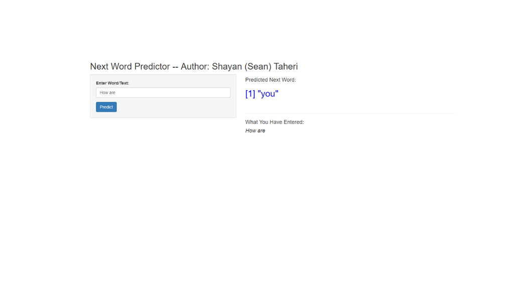

## References

- Access the developed application at: https://shtaheri.shinyapps.io/Data_Science_Capstone
- Finding all the source files for the project at: https://github.com/shayan-taheri/Data_Science_Capstone
- HC Corpora: http://www.corpora.heliohost.org
- Stanford NLP Course: https://www.coursera.org/course/nlp
- Chen-Goodman 1999: http://u.cs.biu.ac.il/~yogo/courses/mt2013/papers/chen-goodman-99.pdf
- Kneser Ney Smoothing: http://www.foldl.me/2014/kneser-ney-smoothing